# statistics

*solution_03_central_limit_theorem/01_standard_normal/04_twotailarea_from_z_v1*

First, you need to identify that we are looking for a two-tail area (the sum of the left and right tails). This is because $z$-scores far from 0 satisfy $|Z|>0.63$, while $z$-scores near 0 do not satisfy the inequality.

Start with a sketch.

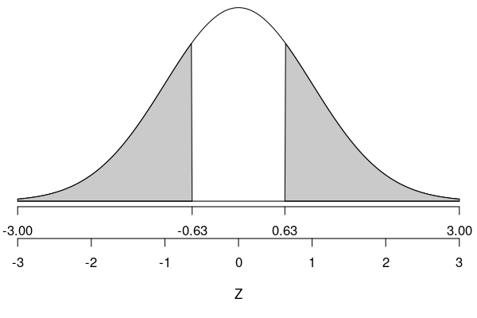

**Method 1:** First find the area of the left tail.
$$P(Z<-0.63) = 0.2643$$
Recognize normal distributions are symmetric, so we also know the area of the right tail.
$$P(Z>0.63) = 0.2643$$
The two areas add to our desired two-tail area.
$$\begin{aligned}
P\left(|Z|>0.63\right) &= P(Z<-0.63)+P(Z>0.63) \\
&= 0.2643 + 0.2643 \\
&= 0.5286
\end{aligned}$$

This technique can be summarized with the following formula:
$$P\left(|Z|>z\right) = 2\cdot P(Z<-z)$$
assuming $z>0$.

This method is shown graphically:

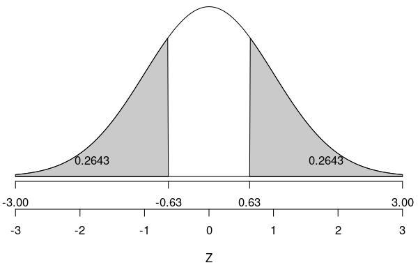

Notice we need to add both tails.

**Method 2:** You can achieve the same result by using the following formula:
$$P\left(|Z|>z\right) = 2\cdot\left[1-P(Z<z) \right]$$
So,
$$\begin{aligned}
P\left(|Z|>0.63\right) &= 2\cdot\left[1-P(Z<0.63) \right] \\
&= 2\cdot\left[1-0.7357\right] \\
&= 2\cdot0.2643\\
&= 0.5286
\end{aligned}$$

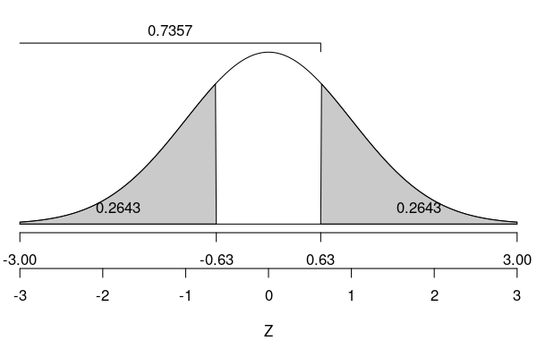

It might be helpful to visualize with a spinner.

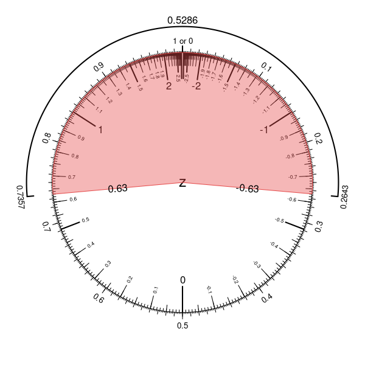

In a spreadsheet, you could use the `NORM.DIST()` function.

```
=2*NORM.DIST(-0.63,0,1,TRUE)
```

In R, you could use the `pnorm` function.

```
2*pnorm(-0.63)
```